# DIIG Data Challenge

Alayna Binder

2023-09-14

## Context

The World Health Organization, as part of a recent initiative to reduce early deaths in developing countries, wants to learn more about what factors have the strongest correlation with life expectancy. Specifically, they would like to confidently fund specific sectors within developing countries that will have the overall greatest impact on improvements in life expectancy. You have been tasked with examining this data to provide guidance for WHO on where you believe they should focus their efforts on.

## Guiding Questions

- Which variables have the strongest positive and negative correlation to high life expectancy?
- Are there any similarities in variable outcomes based on Developed vs Developing countries?
- Are there similar trends when considering various columns related to vaccinations vs income/wealth vs deaths?
- If a disease like Hepatitis B is present at high levels in certain countries, is there correlation with other diseases as well?

*NOTE: Guiding questions are meant to help you get started and brainstorm. You do not need to specifically answer these questions for the presentation. Feel free to explore anything that is of interest to you in the dataset.*

## Data

```
##                                       [,1]
## Year                              1.140054
## Status                            1.826032
## `Adult Mortality`                 1.799131
## Alcohol                           2.310699
## `percentage expenditure`          1.414588
## `Hepatitis B`                     1.689768
## Measles                           1.407407
## BMI                               1.795934
## `under-five deaths`               2.703978
## Polio                             1.710450
## `Total expenditure`               1.123364
## Diphtheria                        2.073713
## `HIV/AIDS`                        1.501108
## Population                        1.827693
## `thinness 5-9 years`              1.953427
## `Income composition of resources` 2.991773
## Schooling                         3.514668
```

```
##
## Call:
## lm(formula = `Life expectancy` ~ ., data = lifeexp_mc)
##
## Residuals:
##      Min       1Q   Median       3Q      Max
## -16.8530  -2.2140   0.0436   2.3300  12.1951
##
## Coefficients:
##                                     Estimate Std. Error t value Pr(>|t|)
## (Intercept)                        3.346e+02  4.677e+01   7.153 1.28e-12 ***
## Year                              -1.409e-01  2.335e-02  -6.033 1.99e-09 ***
## Status1                            9.133e-01  3.413e-01   2.676  0.00753 **
## `Adult Mortality`                 -1.709e-02  9.570e-04 -17.862  < 2e-16 ***
## Alcohol                           -1.799e-01  3.373e-02  -5.335 1.09e-07 ***
## `percentage expenditure`           4.443e-04  6.045e-05   7.350 3.11e-13 ***
## `Hepatitis B`                     -3.570e-03  4.539e-03  -0.786  0.43174
## Measles                            1.388e-05  1.052e-05   1.320  0.18693
## BMI                                3.365e-02  6.065e-03   5.549 3.36e-08 ***
## `under-five deaths`               -2.793e-03  9.025e-04  -3.095  0.00200 **
## Polio                              7.735e-03  5.208e-03   1.485  0.13769
## `Total expenditure`                8.638e-02  4.121e-02   2.096  0.03624 *
## Diphtheria                         1.885e-02  5.966e-03   3.159  0.00161 **
## `HIV/AIDS`                        -4.512e-01  1.816e-02 -24.847  < 2e-16 ***
## Population                         2.881e-09  1.715e-09   1.680  0.09322 .
## `thinness 5-9 years`              -2.997e-02  2.685e-02  -1.116  0.26451
## `Income composition of resources`  1.110e+01  8.446e-01  13.144  < 2e-16 ***
## Schooling                          9.246e-01  5.996e-02  15.419  < 2e-16 ***
## ---
## Signif. codes:  0 '***' 0.001 '**' 0.01 '*' 0.05 '.' 0.1 ' ' 1
##
## Residual standard error: 3.63 on 1631 degrees of freedom
## Multiple R-squared:  0.8315, Adjusted R-squared:  0.8298
## F-statistic: 473.5 on 17 and 1631 DF,  p-value: < 2.2e-16
```

```
## # A tibble: 22 × 3
##    variable               n_miss pct_miss
##    <chr>                   <int>    <dbl>
##  1 Country                     0        0
##  2 Year                        0        0
##  3 Status                      0        0
##  4 Life expectancy             0        0
##  5 Adult Mortality             0        0
##  6 infant deaths               0        0
##  7 Alcohol                     0        0
##  8 percentage expenditure      0        0
##  9 Hepatitis B                 0        0
## 10 Measles                     0        0
## # ℹ 12 more rows
```

```
## # A tibble: 22 × 3
##    variable               n_miss pct_miss
##    <chr>                   <int>    <dbl>
##  1 Country                     0        0
##  2 Year                        0        0
##  3 Status                      0        0
##  4 Life expectancy             0        0
##  5 Adult Mortality             0        0
##  6 infant deaths               0        0
##  7 Alcohol                     0        0
##  8 percentage expenditure      0        0
##  9 Hepatitis B                 0        0
## 10 Measles                     0        0
## # ℹ 12 more rows
```

```
## # A tibble: 22 × 3
##    variable               n_miss pct_miss
##    <chr>                   <int>    <dbl>
##  1 Country                     0        0
##  2 Year                        0        0
##  3 Status                      0        0
##  4 Life expectancy             0        0
##  5 Adult Mortality             0        0
##  6 infant deaths               0        0
##  7 Alcohol                     0        0
##  8 percentage expenditure      0        0
##  9 Hepatitis B                 0        0
## 10 Measles                     0        0
## # ℹ 12 more rows
```

```
## Rows: 1,649
## Columns: 22
## $ Country                           <chr> "Afghanistan", "Afghanistan", "Afgha…
## $ Year                              <dbl> 2015, 2014, 2013, 2012, 2011, 2010, …
## $ Status                            <fct> 0, 0, 0, 0, 0, 0, 0, 0, 0, 0, 0, 0, …
## $ `Life expectancy`                 <dbl> 65.0, 59.9, 59.9, 59.5, 59.2, 58.8, …
## $ `Adult Mortality`                 <dbl> 263, 271, 268, 272, 275, 279, 281, 2…
## $ `infant deaths`                   <dbl> 62, 64, 66, 69, 71, 74, 77, 80, 82, …
## $ Alcohol                           <dbl> 0.01, 0.01, 0.01, 0.01, 0.01, 0.01, …
## $ `percentage expenditure`          <dbl> 71.279624, 73.523582, 73.219243, 78.…
## $ `Hepatitis B`                     <dbl> 65, 62, 64, 67, 68, 66, 63, 64, 63, …
## $ Measles                           <dbl> 1154, 492, 430, 2787, 3013, 1989, 28…
## $ BMI                               <dbl> 19.1, 18.6, 18.1, 17.6, 17.2, 16.7, …
## $ `under-five deaths`               <dbl> 83, 86, 89, 93, 97, 102, 106, 110, 1…
## $ Polio                             <dbl> 6, 58, 62, 67, 68, 66, 63, 64, 63, 5…
## $ `Total expenditure`               <dbl> 8.16, 8.18, 8.13, 8.52, 7.87, 9.20, …
## $ Diphtheria                        <dbl> 65, 62, 64, 67, 68, 66, 63, 64, 63, …
## $ `HIV/AIDS`                        <dbl> 0.1, 0.1, 0.1, 0.1, 0.1, 0.1, 0.1, 0…
## $ GDP                               <dbl> 584.25921, 612.69651, 631.74498, 669…
## $ Population                        <dbl> 33736494, 327582, 31731688, 3696958,…
## $ `thinness  1-19 years`            <dbl> 17.2, 17.5, 17.7, 17.9, 18.2, 18.4, …
## $ `thinness 5-9 years`              <dbl> 17.3, 17.5, 17.7, 18.0, 18.2, 18.4, …
## $ `Income composition of resources` <dbl> 0.479, 0.476, 0.470, 0.463, 0.454, 0…
## $ Schooling                         <dbl> 10.1, 10.0, 9.9, 9.8, 9.5, 9.2, 8.9,…
```

### Variables

- Status: Developed or Developing country.
- Year: There are several data points for many countries so consider various years!
- Adult Mortality: Probability of dying between 15 - 60 years per 1000 population.
- Infant Deaths: Number of infant deaths per 1000 population.
- Alcohol: Alcohol, recorded per capita (15+) consumption (in liters of pure alcohol).
- Percentage Expenditure: Expenditure on health as a % of GDP.
- Hepatitis B/Polio/Diphtheria: HepB/Polio/Diphtheria immunization coverage among 1-year-olds.
- Measles: Number of cases per 1000 population.
- BMI: Average BMI of the entire population.
- Total Expenditure: General government expenditure on health as a percentage of total government expenditure.
- HIV/AIDS: Deaths per 1000 live births HIV/AIDS (0-4 years)
- Thinness: Prevalence of thinness among children and adolescents for age interval.
- Income Composition: Human Development Index in terms of income composition of resources (index ranging from 0 to 1.)
- Schooling: Number of years of schooling.

### Missing Data

In practice, we want to avoid using variables that have more than 10% missingness to avoid bias. In this data set, `Population` (22.2%), `Hepatitis B` (18.8%), and `GDP` (15.2%) all have more than 10% missingness. Data imputation, however, is not appropriate in this scenario because the data is not missing at random. Certain countries have missing data in several variable columns, sometimes over a span of several years, so imputing data may cause misleading results. Since this analysis is focused on reviewing general factors and not specific countries, missing values are dropped. Dropping the NAs in population removes all NAs in the data set.

## Exploratory Data Analysis

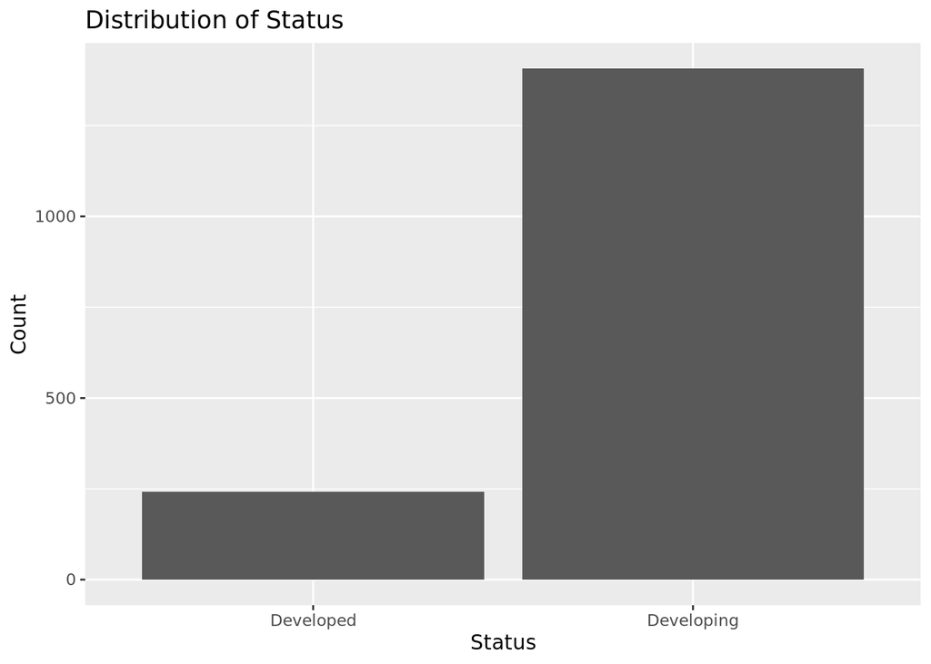

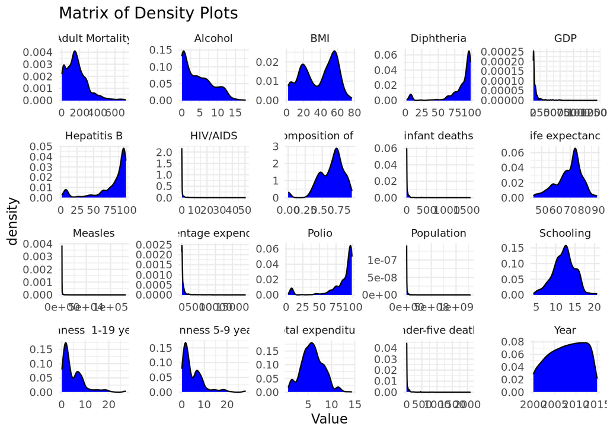

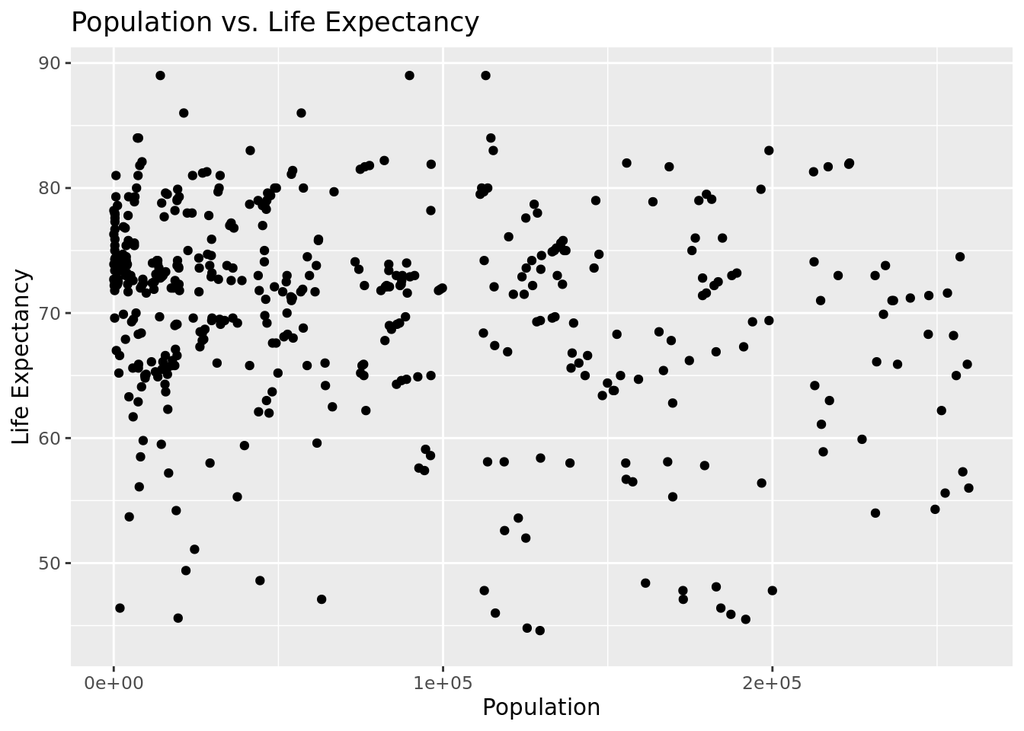

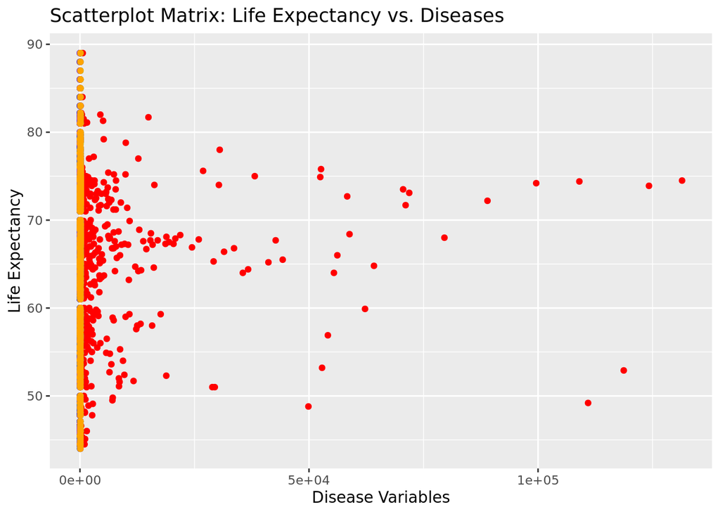

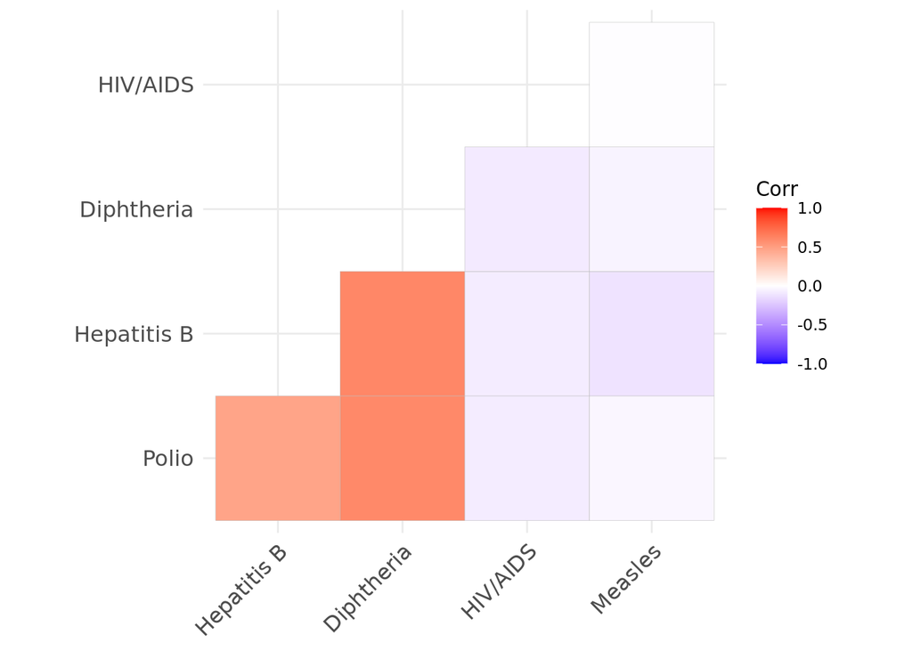

Explains why initial disease scatter plot is not an informative visual.

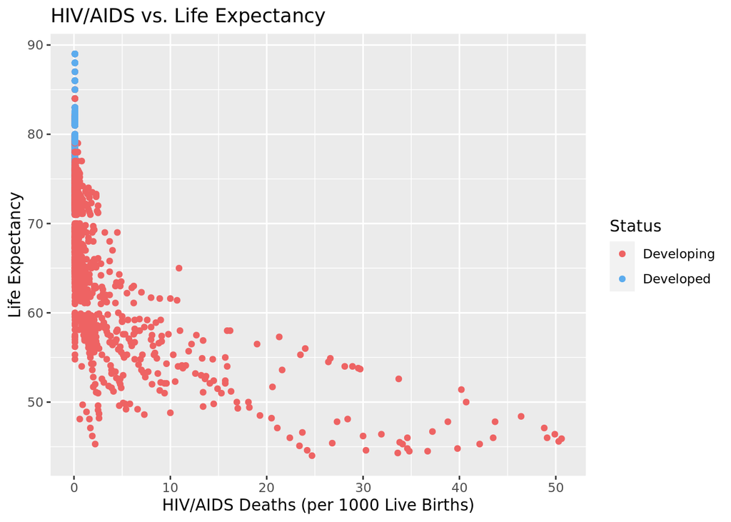

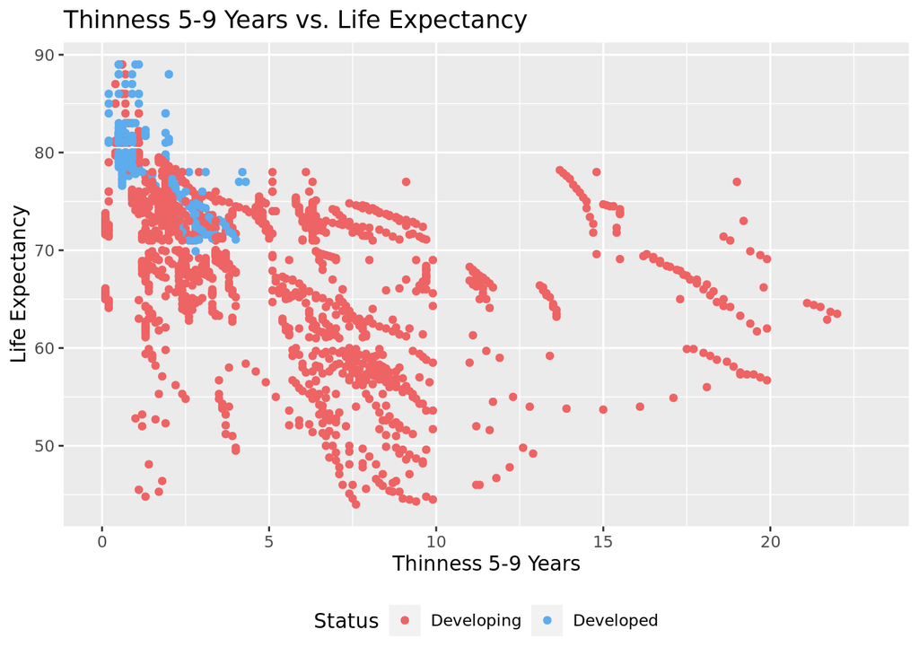

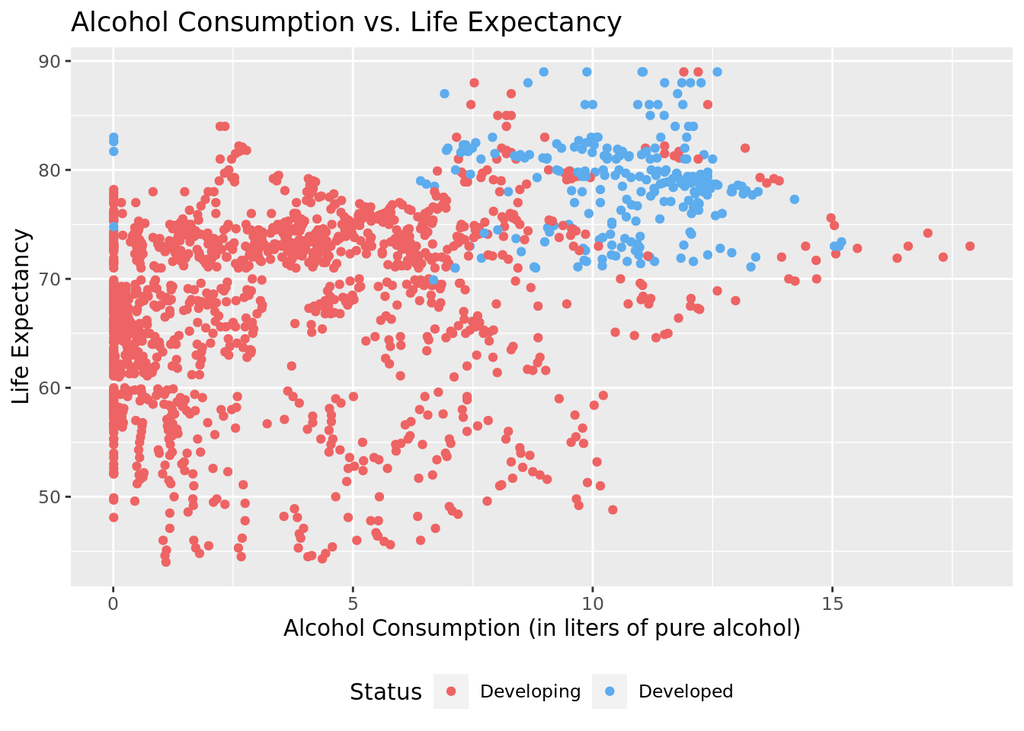

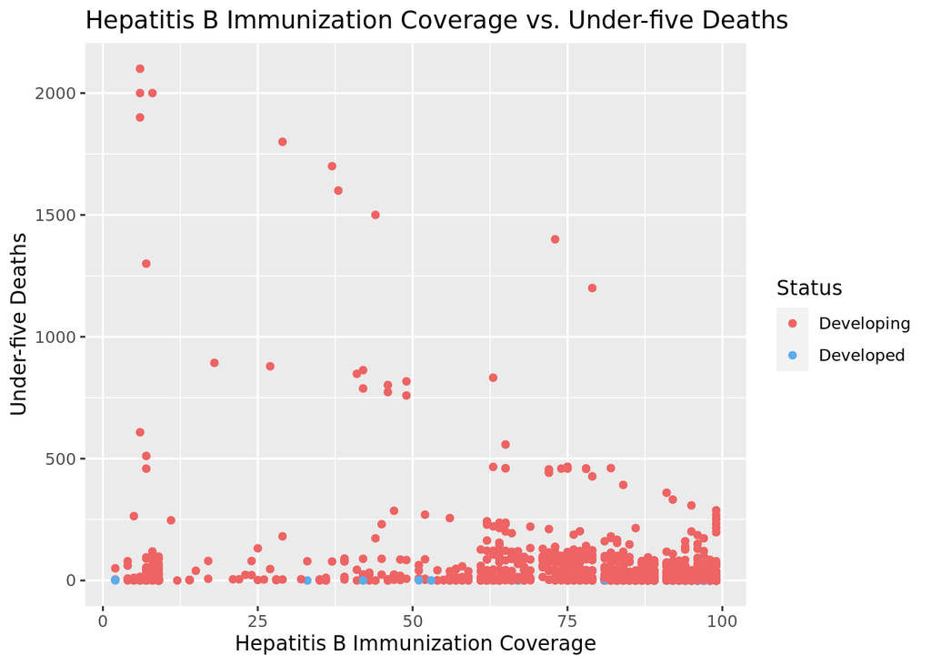

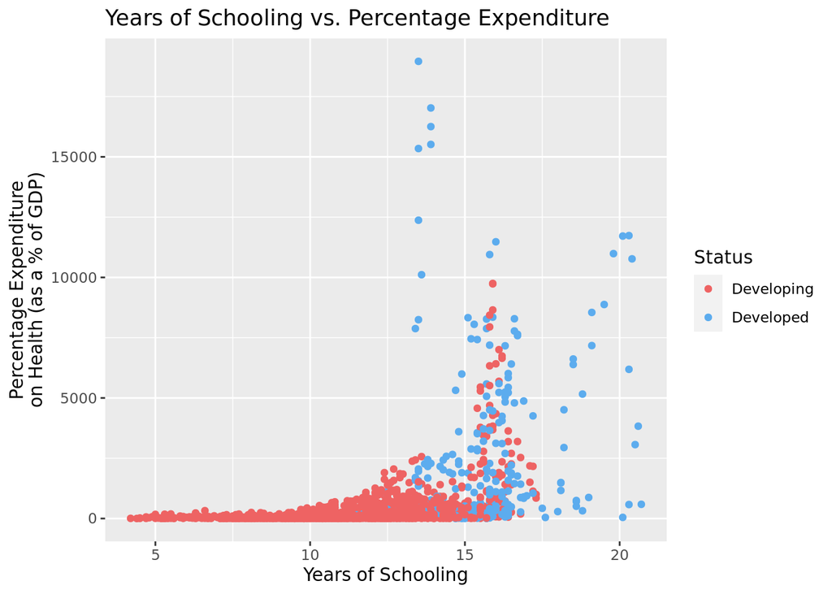

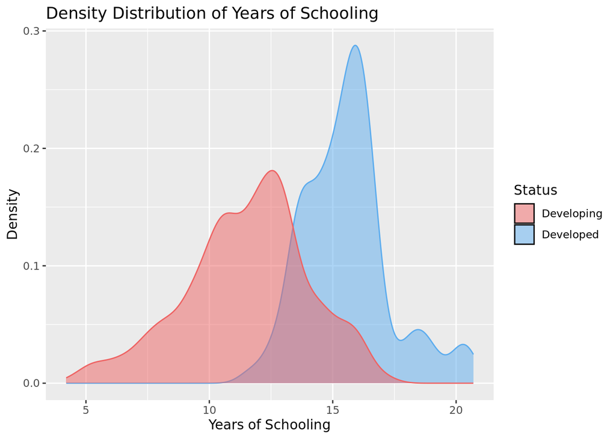

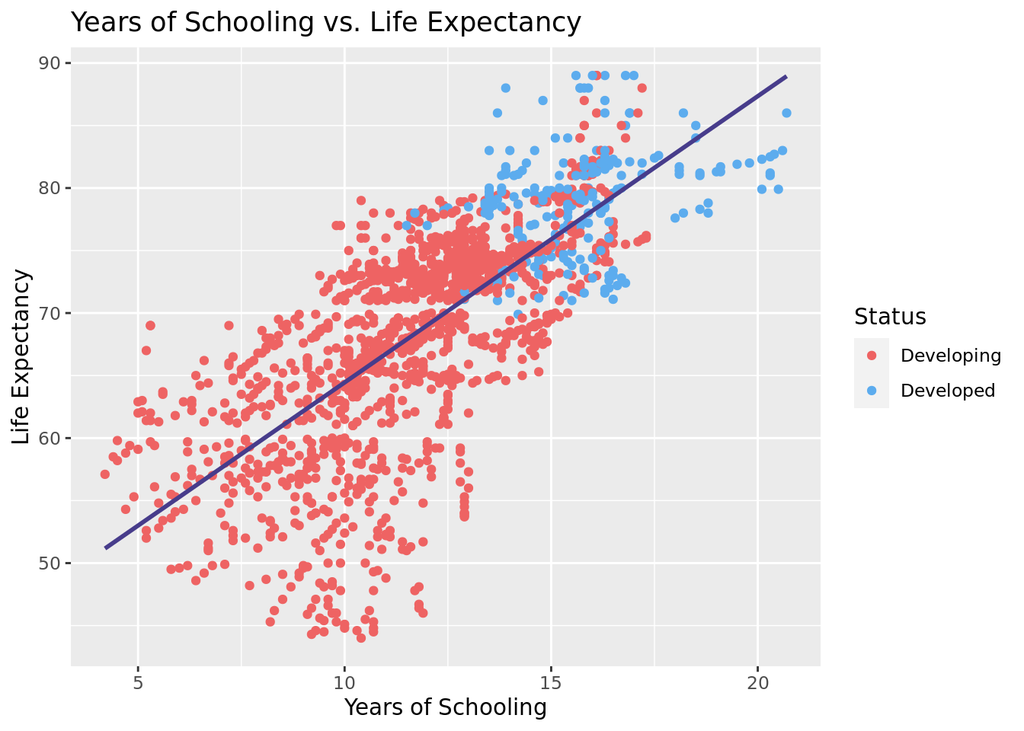

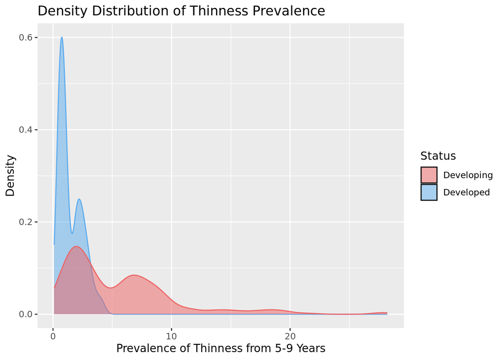

```r
sp8 <- ggplot(lifeexp_school_scatter,
       aes(x = `thinness 5-9 years`, fill = Status)) +
  geom_density(aes(color = Status), alpha = 0.5) +  # Use color aesthetic
  labs(x = "Prevalence of Thinness from 5-9 Years",
       y = "Density",
       title = "Density Distribution of Thinness Prevalence") +
  guides(fill = guide_legend(reverse = TRUE)) +
  scale_fill_manual(values = c("Developing" = "indianred2", "Developed" = "steelblue2")) +
  scale_color_manual(values = c("Developing" = "indianred2", "Developed" = "steelblue2")) +
  guides(color = FALSE)

sp8
```

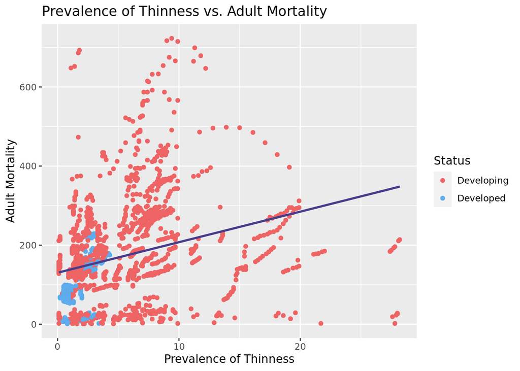

[output not shown]

```r
# ----------------------------------------------------------------------------

sp9 <- ggplot(lifeexp_school_scatter,
       aes(x = `thinness 5-9 years`, y = `Adult Mortality`, color = Status)) +
  geom_point() +
  geom_smooth(method = "lm", se = FALSE, color = "slateblue4") +
  labs(x = "Prevalence of Thinness",
       y = "Adult Mortality",
       title = "Prevalence of Thinness vs. Adult Mortality") +
  guides(color = guide_legend(reverse=TRUE))

sp9 + scale_color_manual(values = c("steelblue2", "indianred2"))
```